# 🏦 IBKR ISA Portfolio — Comprehensive Analysis

### 29 Holdings | Multi-Asset Global Portfolio

### Analysis Date: February 2026 | Lookback: 2 Years

**Analyst Toolkit:** yfinance · Riskfolio-Lib · PyFolio · QuantStats · Plotly · Seaborn

## 1. Setup & Configuration

```python
# ============================================================
# 1.1 — Install & Import Libraries
# ============================================================
import warnings
warnings.filterwarnings('ignore')

import numpy as np
import pandas as pd
import yfinance as yf
import matplotlib.pyplot as plt
import matplotlib.dates as mdates
import seaborn as sns
import plotly.express as px
import plotly.graph_objects as go
from plotly.subplots import make_subplots
import plotly.io as pio

from scipy import stats
from datetime import datetime, timedelta
import calendar

# Riskfolio
import riskfolio as rp

# Styling
sns.set_theme(style="darkgrid", palette="deep")
plt.rcParams.update({
    'figure.figsize': (14, 7),
    'font.size': 12,
    'axes.titlesize': 14,
    'axes.labelsize': 12,
    'figure.dpi': 100,
    'savefig.dpi': 150,
    'figure.facecolor': '#0e1117',
    'axes.facecolor': '#1a1a2e',
    'text.color': 'white',
    'axes.labelcolor': 'white',
    'xtick.color': 'white',
    'ytick.color': 'white',
})
pio.templates.default = "plotly_dark"

print("✅ All libraries loaded successfully")
```

```
✅ All libraries loaded successfully
```

## 2. Portfolio Definition

Holdings extracted from IBKR ISA screenshots. Weights represent %NetLiq allocations, normalised to sum to 100% for the invested capital portion.

**Thematic Breakdown:**

- **AI / Tech:** GOOGL, AMZN, NVDA, BABA, BIDU, 1810.HK, NIO, MELI, NBIS, WYFI
- **Nuclear / Energy:** OKLO, LEU, BE, XOM, HAL
- **Precious Metals:** SGLN (Gold ETC), KGC, PAAS
- **Critical Minerals / Lithium:** PLS.AX, LAC, PMET.TO, LTR.AX, LAR, LKY.AX, ARG.TO
- **UK / Defence:** BARC.L, RR.L, ACG.L, DRO.AX

```python
# ============================================================
# 2.1 — Portfolio Holdings & Weights
# ============================================================

# Ticker mapping: display name -> yfinance ticker
holdings = {
    'GOOGL':   {'yf_ticker': 'GOOGL',   'weight': 8.23, 'sector': 'Technology',       'theme': 'AI / Big Tech'},
    'SGLN':    {'yf_ticker': 'SGLN.L',   'weight': 7.80, 'sector': 'Commodities',      'theme': 'Precious Metals'},
    'AMZN':    {'yf_ticker': 'AMZN',     'weight': 6.28, 'sector': 'Technology',       'theme': 'AI / Big Tech'},
    'KGC':     {'yf_ticker': 'KGC',      'weight': 5.51, 'sector': 'Materials',        'theme': 'Precious Metals'},
    'PLS':     {'yf_ticker': 'PLS.AX',   'weight': 5.39, 'sector': 'Materials',        'theme': 'Critical Minerals'},
    'BARC':    {'yf_ticker': 'BARC.L',   'weight': 4.87, 'sector': 'Financials',       'theme': 'UK Equity'},
    'OKLO':    {'yf_ticker': 'OKLO',     'weight': 4.52, 'sector': 'Energy',           'theme': 'Nuclear'},
    'RR':      {'yf_ticker': 'RR.L',     'weight': 4.38, 'sector': 'Industrials',      'theme': 'UK Defence/Aero'},
    'LEU':     {'yf_ticker': 'LEU',      'weight': 3.56, 'sector': 'Energy',           'theme': 'Nuclear'},
    'NVDA':    {'yf_ticker': 'NVDA',     'weight': 3.32, 'sector': 'Technology',       'theme': 'AI / Semis'},
    'BABA':    {'yf_ticker': 'BABA',     'weight': 2.43, 'sector': 'Technology',       'theme': 'China Tech'},
    'WYFI':    {'yf_ticker': 'WYFI',     'weight': 2.36, 'sector': 'Technology',       'theme': 'AI / Data'},
    'XOM':     {'yf_ticker': 'XOM',      'weight': 2.23, 'sector': 'Energy',           'theme': 'Trad Energy'},
    'BIDU':    {'yf_ticker': 'BIDU',     'weight': 2.18, 'sector': 'Technology',       'theme': 'China Tech'},
    'BE':      {'yf_ticker': 'BE',       'weight': 2.15, 'sector': 'Energy',           'theme': 'Clean Energy'},
    'HAL':     {'yf_ticker': 'HAL',      'weight': 2.09, 'sector': 'Energy',           'theme': 'Trad Energy'},
    'NBIS':    {'yf_ticker': 'NBIS',     'weight': 1.94, 'sector': 'Technology',       'theme': 'AI / Data'},
    'PAAS':    {'yf_ticker': 'PAAS',     'weight': 1.65, 'sector': 'Materials',        'theme': 'Precious Metals'},
    'DRO':     {'yf_ticker': 'DRO.AX',   'weight': 1.52, 'sector': 'Industrials',      'theme': 'Defence Tech'},
    'ARG':     {'yf_ticker': 'ARG.TO',   'weight': 1.52, 'sector': 'Materials',        'theme': 'Critical Minerals'},
    'LAR':     {'yf_ticker': 'LAR',      'weight': 1.52, 'sector': 'Materials',        'theme': 'Critical Minerals'},
    'MELI':    {'yf_ticker': 'MELI',     'weight': 1.47, 'sector': 'Technology',       'theme': 'LatAm Tech'},
    'LAC':     {'yf_ticker': 'LAC',      'weight': 1.40, 'sector': 'Materials',        'theme': 'Critical Minerals'},
    'PMET':    {'yf_ticker': 'PMET.TO',  'weight': 1.38, 'sector': 'Materials',        'theme': 'Critical Minerals'},
    'XIAOMI':  {'yf_ticker': '1810.HK',  'weight': 1.34, 'sector': 'Technology',       'theme': 'China Tech'},
    'NIO':     {'yf_ticker': 'NIO',      'weight': 1.33, 'sector': 'Consumer Disc.',   'theme': 'China EV'},
    'LTR':     {'yf_ticker': 'LTR.AX',   'weight': 1.23, 'sector': 'Materials',        'theme': 'Critical Minerals'},
    'ACG':     {'yf_ticker': 'ACG.L',    'weight': 0.78, 'sector': 'Financials',       'theme': 'UK Equity'},
    'LKY':     {'yf_ticker': 'LKY.AX',   'weight': 0.16, 'sector': 'Materials',        'theme': 'Critical Minerals'},
}

# Create summary DataFrame
portfolio_df = pd.DataFrame(holdings).T
portfolio_df['weight'] = portfolio_df['weight'].astype(float)

# Normalise weights to sum to 100%
portfolio_df['weight_norm'] = portfolio_df['weight'] / portfolio_df['weight'].sum() * 100

print(f"Portfolio: {len(holdings)} holdings")
print(f"Raw weight sum: {portfolio_df['weight'].sum():.2f}%")
print(f"Normalised weight sum: {portfolio_df['weight_norm'].sum():.2f}%")
print(f"Portfolio value: £98,303")
print()
portfolio_df[['yf_ticker', 'weight', 'weight_norm', 'sector', 'theme']].to_string()
portfolio_df[['yf_ticker', 'weight', 'weight_norm', 'sector', 'theme']]
```

```
Portfolio: 29 holdings
Raw weight sum: 84.54%
Normalised weight sum: 100.00%
Portfolio value: £98,303
```

|  | yf_ticker | weight | weight_norm | sector | theme |
| --- | --- | --- | --- | --- | --- |
| GOOGL | GOOGL | 8.23 | 9.735037 | Technology | AI / Big Tech |
| SGLN | SGLN.L | 7.80 | 9.226402 | Commodities | Precious Metals |
| AMZN | AMZN | 6.28 | 7.428436 | Technology | AI / Big Tech |
| KGC | KGC | 5.51 | 6.517625 | Materials | Precious Metals |
| PLS | PLS.AX | 5.39 | 6.375680 | Materials | Critical Minerals |
| BARC | BARC.L | 4.87 | 5.760587 | Financials | UK Equity |
| OKLO | OKLO | 4.52 | 5.346581 | Energy | Nuclear |
| RR | RR.L | 4.38 | 5.180979 | Industrials | UK Defence/Aero |
| LEU | LEU | 3.56 | 4.211024 | Energy | Nuclear |
| NVDA | NVDA | 3.32 | 3.927135 | Technology | AI / Semis |
| BABA | BABA | 2.43 | 2.874379 | Technology | China Tech |
| WYFI | WYFI | 2.36 | 2.791578 | Technology | AI / Data |
| XOM | XOM | 2.23 | 2.637805 | Energy | Trad Energy |
| BIDU | BIDU | 2.18 | 2.578661 | Technology | China Tech |
| BE | BE | 2.15 | 2.543175 | Energy | Clean Energy |
| HAL | HAL | 2.09 | 2.472203 | Energy | Trad Energy |
| NBIS | NBIS | 1.94 | 2.294772 | Technology | AI / Data |
| PAAS | PAAS | 1.65 | 1.951739 | Materials | Precious Metals |
| DRO | DRO.AX | 1.52 | 1.797965 | Industrials | Defence Tech |
| ARG | ARG.TO | 1.52 | 1.797965 | Materials | Critical Minerals |
| LAR | LAR | 1.52 | 1.797965 | Materials | Critical Minerals |
| MELI | MELI | 1.47 | 1.738822 | Technology | LatAm Tech |
| LAC | LAC | 1.40 | 1.656021 | Materials | Critical Minerals |
| PMET | PMET.TO | 1.38 | 1.632363 | Materials | Critical Minerals |
| XIAOMI | 1810.HK | 1.34 | 1.585048 | Technology | China Tech |
| NIO | NIO | 1.33 | 1.573220 | Consumer Disc. | China EV |
| LTR | LTR.AX | 1.23 | 1.454933 | Materials | Critical Minerals |
| ACG | ACG.L | 0.78 | 0.922640 | Financials | UK Equity |
| LKY | LKY.AX | 0.16 | 0.189260 | Materials | Critical Minerals |

## 3. Data Download (2-Year Lookback)

Downloading adjusted close prices for all holdings plus benchmarks (SPY, ACWI) from yfinance. Handling missing data and newly-listed tickers gracefully.

```python
# ============================================================
# 3.1 — Download Price Data
# ============================================================

# Tickers to download
yf_tickers = [h['yf_ticker'] for h in holdings.values()]
benchmark_tickers = ['SPY', 'ACWI']  # S&P 500 & MSCI ACWI
all_tickers = yf_tickers + benchmark_tickers

# Date range: 2 years
end_date = datetime.now()
start_date = end_date - timedelta(days=2*365)

print(f"Downloading data from {start_date.strftime('%Y-%m-%d')} to {end_date.strftime('%Y-%m-%d')}")
print(f"Tickers: {len(all_tickers)}")
print()

# Download all data
raw_data = yf.download(all_tickers, start=start_date, end=end_date, auto_adjust=True, progress=True)

# Extract Close prices
if isinstance(raw_data.columns, pd.MultiIndex):
    prices = raw_data['Close'].copy()
else:
    prices = raw_data[['Close']].copy()

# Check for failed downloads
available = prices.columns[prices.notna().sum() > 10].tolist()
failed = [t for t in all_tickers if t not in available]
if failed:
    print(f"\n⚠️ Failed/insufficient data for: {failed}")
    print("These will be excluded from analysis.")

# Keep only valid tickers
prices = prices[available].copy()

# Forward fill then backfill small gaps
prices = prices.ffill().bfill()

# Drop any remaining rows with all NaN
prices = prices.dropna(how='all')

print(f"\n✅ Successfully loaded {len([t for t in available if t not in benchmark_tickers])} holdings + {len([t for t in available if t in benchmark_tickers])} benchmarks")
print(f"Date range: {prices.index[0].strftime('%Y-%m-%d')} to {prices.index[-1].strftime('%Y-%m-%d')}")
print(f"Trading days: {len(prices)}")
```

```
Downloading data from 2024-02-08 to 2026-02-07
Tickers: 31
```

```
[*********************100%***********************]  31 of 31 completed
```

```
✅ Successfully loaded 29 holdings + 2 benchmarks
Date range: 2024-02-08 to 2026-02-06
Trading days: 516
```

```python
# ============================================================
# 3.2 — Compute Returns
# ============================================================

# Daily returns
returns = prices.pct_change().dropna()

# Separate portfolio tickers from benchmarks
port_tickers = [t for t in available if t not in benchmark_tickers]

# Build weight vector (aligned with available tickers, normalised)
name_to_yf = {k: v['yf_ticker'] for k, v in holdings.items()}
yf_to_weight = {}
for name, info in holdings.items():
    yf_to_weight[info['yf_ticker']] = info['weight']

weights_series = pd.Series({t: yf_to_weight.get(t, 0) for t in port_tickers})
weights_series = weights_series / weights_series.sum()  # normalise

# Portfolio daily returns (weighted)
port_returns = (returns[port_tickers] * weights_series).sum(axis=1)
port_returns.name = 'Portfolio'

# Benchmark returns
bench_returns = {}
for b in benchmark_tickers:
    if b in returns.columns:
        bench_returns[b] = returns[b]

# Combined returns for comparison
combined_returns = pd.DataFrame({'Portfolio': port_returns})
for b, r in bench_returns.items():
    combined_returns[b] = r
combined_returns = combined_returns.dropna()

# Cumulative returns
cum_returns = (1 + combined_returns).cumprod() - 1

print("✅ Returns computed")
print(f"Portfolio daily return mean: {port_returns.mean()*252:.2%} (annualised)")
print(f"Portfolio daily return std:  {port_returns.std()*np.sqrt(252):.2%} (annualised)")
```

```
✅ Returns computed
Portfolio daily return mean: 58.45% (annualised)
Portfolio daily return std:  23.91% (annualised)
```

## 4. Portfolio Overview & Allocation

### 4.1 Sector & Thematic Allocation

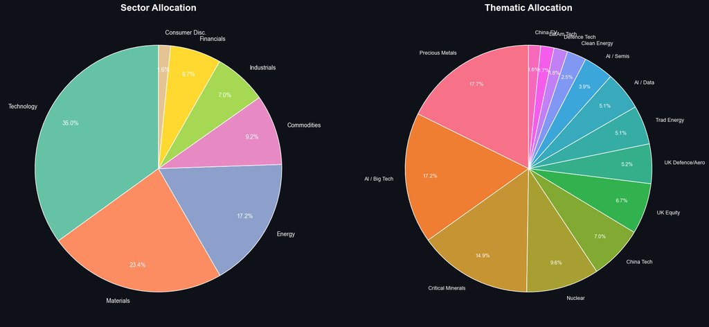

```
Top 3 sectors: {'Technology': 34.95386799148333, 'Materials': 23.373550981783772, 'Energy': 17.210787792760822}
Top 3 themes: {'Precious Metals': 17.695765318192574, 'AI / Big Tech': 17.1634729122309, 'Critical Minerals': 14.9041873669269}
```

```python
# ============================================================
# 4.1 — Sector Breakdown (Pie Charts)
# ============================================================

fig, axes = plt.subplots(1, 2, figsize=(18, 8))
fig.patch.set_facecolor('#0e1117')

# Sector allocation
sector_weights = portfolio_df.groupby('sector')['weight_norm'].sum().sort_values(ascending=False)
colors_sector = sns.color_palette("Set2", len(sector_weights))
wedges1, texts1, autotexts1 = axes[0].pie(
    sector_weights.values, labels=sector_weights.index, autopct='%1.1f%%',
    colors=colors_sector, startangle=90, pctdistance=0.8,
    textprops={'color': 'white', 'fontsize': 10}
)
axes[0].set_title('Sector Allocation', fontsize=16, color='white', fontweight='bold')

# Theme allocation
theme_weights = portfolio_df.groupby('theme')['weight_norm'].sum().sort_values(ascending=False)
colors_theme = sns.color_palette("husl", len(theme_weights))
wedges2, texts2, autotexts2 = axes[1].pie(
    theme_weights.values, labels=theme_weights.index, autopct='%1.1f%%',
    colors=colors_theme, startangle=90, pctdistance=0.8,
    textprops={'color': 'white', 'fontsize': 9}
)
axes[1].set_title('Thematic Allocation', fontsize=16, color='white', fontweight='bold')

plt.tight_layout()
plt.savefig('sector_theme_allocation.png', bbox_inches='tight', facecolor='#0e1117')
plt.show()
print("Top 3 sectors:", sector_weights.head(3).to_dict())
print("Top 3 themes:", theme_weights.head(3).to_dict())
```

```python
# ============================================================
# 4.2 — Interactive Treemap (Plotly)
# ============================================================

treemap_data = portfolio_df.reset_index()
treemap_data.columns = ['Name'] + list(treemap_data.columns[1:])
treemap_data['value_gbp'] = treemap_data['weight_norm'] / 100 * 98303

fig = px.treemap(
    treemap_data,
    path=['theme', 'sector', 'Name'],
    values='weight_norm',
    color='weight_norm',
    color_continuous_scale='Viridis',
    title='Portfolio Treemap — Theme > Sector > Holding',
    custom_data=['value_gbp']
)
fig.update_traces(
    texttemplate='%{label}<br>%{value:.1f}%<br>£%{customdata[0]:,.0f}',
    textfont_size=11
)
fig.update_layout(height=700, margin=dict(t=50, l=25, r=25, b=25))
fig.show()
```

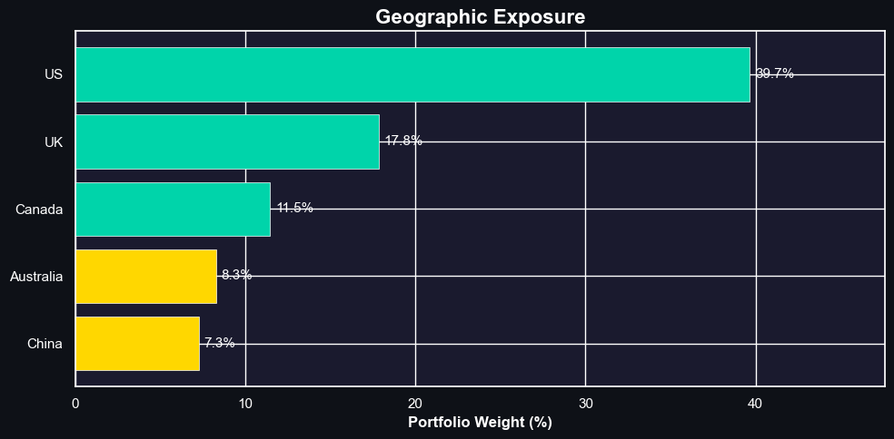

```python
# ============================================================
# 4.3 — Geographic Exposure
# ============================================================

geo_map = {
    'GOOGL': 'US', 'AMZN': 'US', 'NVDA': 'US', 'XOM': 'US', 'HAL': 'US',
    'KGC': 'Canada', 'PAAS': 'Canada', 'LAC': 'Canada', 'MELI': 'US',
    'BABA': 'China', 'BIDU': 'China', 'NIO': 'China', 'XIAOMI': 'China',
    'BARC': 'UK', 'RR': 'UK', 'ACG': 'UK', 'SGLN': 'UK',
    'PLS': 'Australia', 'DRO': 'Australia', 'LTR': 'Australia', 'LKY': 'Australia',
    'ARG': 'Canada', 'PMET': 'Canada',
    'OKLO': 'US', 'LEU': 'US', 'BE': 'US', 'WYFI': 'US', 'NBIS': 'US',
    'LAR': 'US',
}

geo_weights = {}
for name, info in holdings.items():
    country = geo_map.get(name, 'Other')
    geo_weights[country] = geo_weights.get(country, 0) + info['weight']

geo_df = pd.Series(geo_weights).sort_values(ascending=True)

fig, ax = plt.subplots(figsize=(10, 5))
fig.patch.set_facecolor('#0e1117')
colors = ['#00d4aa' if v > 10 else '#ffd700' if v > 5 else '#ff6b6b' for v in geo_df.values]
bars = ax.barh(geo_df.index, geo_df.values, color=colors, edgecolor='white', linewidth=0.5)
ax.set_xlabel('Portfolio Weight (%)', fontweight='bold')
ax.set_title('Geographic Exposure', fontsize=16, fontweight='bold')
for bar, val in zip(bars, geo_df.values):
    ax.text(bar.get_width() + 0.3, bar.get_y() + bar.get_height()/2, f'{val:.1f}%',
            va='center', fontsize=11, color='white')
ax.set_xlim(0, geo_df.max() * 1.2)
plt.tight_layout()
plt.savefig('geographic_exposure.png', bbox_inches='tight', facecolor='#0e1117')
plt.show()
```

## 5. Portfolio Performance Analysis

### Cumulative returns vs S&P 500 and MSCI ACWI benchmarks

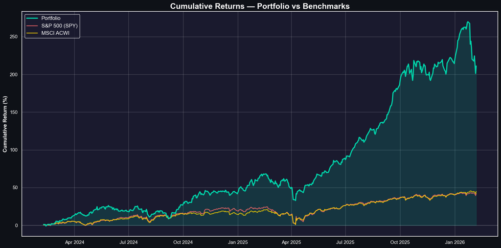

```
Portfolio: 211.08%
SPY: 42.02%
ACWI: 44.83%
```

```python
# ============================================================
# 5.1 — Cumulative Returns (Matplotlib)
# ============================================================

fig, ax = plt.subplots(figsize=(16, 8))
fig.patch.set_facecolor('#0e1117')

ax.plot(cum_returns.index, cum_returns['Portfolio'] * 100, label='Portfolio',
        color='#00d4aa', linewidth=2.5, zorder=5)
if 'SPY' in cum_returns.columns:
    ax.plot(cum_returns.index, cum_returns['SPY'] * 100, label='S&P 500 (SPY)',
            color='#ff6b6b', linewidth=1.8, alpha=0.8)
if 'ACWI' in cum_returns.columns:
    ax.plot(cum_returns.index, cum_returns['ACWI'] * 100, label='MSCI ACWI',
            color='#ffd700', linewidth=1.8, alpha=0.8)

ax.fill_between(cum_returns.index, cum_returns['Portfolio'] * 100, alpha=0.15, color='#00d4aa')
ax.axhline(y=0, color='white', linewidth=0.5, alpha=0.3)
ax.set_title('Cumulative Returns — Portfolio vs Benchmarks', fontsize=18, fontweight='bold')
ax.set_ylabel('Cumulative Return (%)', fontweight='bold')
ax.legend(fontsize=12, loc='upper left', facecolor='#1a1a2e', edgecolor='white')
ax.xaxis.set_major_formatter(mdates.DateFormatter('%b %Y'))
ax.grid(alpha=0.2)
plt.tight_layout()
plt.savefig('cumulative_returns.png', bbox_inches='tight', facecolor='#0e1117')
plt.show()

# Print final returns
for col in cum_returns.columns:
    print(f"{col}: {cum_returns[col].iloc[-1]:.2%}")
```

```python
# ============================================================
# 5.2 — Interactive Cumulative Returns (Plotly)
# ============================================================

fig = go.Figure()

fig.add_trace(go.Scatter(
    x=cum_returns.index, y=cum_returns['Portfolio'] * 100,
    name='Portfolio', line=dict(color='#00d4aa', width=3),
    fill='tozeroy', fillcolor='rgba(0,212,170,0.1)'
))
for bench in ['SPY', 'ACWI']:
    if bench in cum_returns.columns:
        fig.add_trace(go.Scatter(
            x=cum_returns.index, y=cum_returns[bench] * 100,
            name=bench, line=dict(width=2, dash='dot')
        ))

fig.update_layout(
    title='Interactive Cumulative Returns',
    yaxis_title='Cumulative Return (%)',
    hovermode='x unified',
    height=550,
    legend=dict(x=0.01, y=0.99)
)
fig.show()
```

## 6. Key Portfolio Metrics & Ratios

Comprehensive risk-return metrics computed on daily data, annualised where appropriate.

```python
# ============================================================
# 6.1 — Performance Metrics Table
# ============================================================

def compute_metrics(returns_series, rf_annual=0.045):
    """Compute comprehensive portfolio metrics."""
    rf_daily = (1 + rf_annual) ** (1/252) - 1
    excess = returns_series - rf_daily

    ann_ret = returns_series.mean() * 252
    ann_vol = returns_series.std() * np.sqrt(252)
    sharpe = excess.mean() / returns_series.std() * np.sqrt(252) if returns_series.std() > 0 else 0

    # Sortino (downside deviation)
    downside = returns_series[returns_series < 0]
    downside_std = downside.std() * np.sqrt(252)
    sortino = (ann_ret - rf_annual) / downside_std if downside_std > 0 else 0

    # Max Drawdown
    cum = (1 + returns_series).cumprod()
    running_max = cum.cummax()
    drawdowns = (cum - running_max) / running_max
    max_dd = drawdowns.min()

    # Calmar Ratio
    calmar = ann_ret / abs(max_dd) if max_dd != 0 else 0

    # VaR & CVaR (95%)
    var_95 = np.percentile(returns_series, 5)
    cvar_95 = returns_series[returns_series <= var_95].mean()

    # Win rate
    win_rate = (returns_series > 0).sum() / len(returns_series)

    # Skewness & Kurtosis
    skew = returns_series.skew()
    kurt = returns_series.kurtosis()

    # Best / Worst day
    best_day = returns_series.max()
    worst_day = returns_series.min()

    # Gain-to-Pain ratio
    gain_to_pain = returns_series.sum() / abs(returns_series[returns_series < 0].sum()) if abs(returns_series[returns_series < 0].sum()) > 0 else 0

    return {
        'Annual Return': f'{ann_ret:.2%}',
        'Annual Volatility': f'{ann_vol:.2%}',
        'Sharpe Ratio (rf=4.5%)': f'{sharpe:.3f}',
        'Sortino Ratio': f'{sortino:.3f}',
        'Calmar Ratio': f'{calmar:.3f}',
        'Max Drawdown': f'{max_dd:.2%}',
        'VaR (95% daily)': f'{var_95:.2%}',
        'CVaR (95% daily)': f'{cvar_95:.2%}',
        'Win Rate (daily)': f'{win_rate:.2%}',
        'Best Day': f'{best_day:.2%}',
        'Worst Day': f'{worst_day:.2%}',
        'Skewness': f'{skew:.3f}',
        'Excess Kurtosis': f'{kurt:.3f}',
        'Gain/Pain Ratio': f'{gain_to_pain:.3f}',
    }

# Compute for all
metrics_dict = {}
metrics_dict['Portfolio'] = compute_metrics(combined_returns['Portfolio'])
for bench in ['SPY', 'ACWI']:
    if bench in combined_returns.columns:
        metrics_dict[bench] = compute_metrics(combined_returns[bench])

metrics_table = pd.DataFrame(metrics_dict)
print("=" * 70)
print("KEY PORTFOLIO METRICS")
print("=" * 70)
metrics_table
```

```
======================================================================
KEY PORTFOLIO METRICS
======================================================================
```

|  | Portfolio | SPY | ACWI |
| --- | --- | --- | --- |
| Annual Return | 58.45% | 18.47% | 19.19% |
| Annual Volatility | 23.91% | 16.18% | 14.63% |
| Sharpe Ratio (rf=4.5%) | 2.261 | 0.869 | 1.011 |
| Sortino Ratio | 3.055 | 1.084 | 1.282 |
| Calmar Ratio | 2.783 | 0.985 | 1.160 |
| Max Drawdown | -21.00% | -18.76% | -16.55% |
| VaR (95% daily) | -2.24% | -1.52% | -1.33% |
| CVaR (95% daily) | -3.44% | -2.36% | -2.11% |
| Win Rate (daily) | 58.25% | 55.92% | 54.56% |
| Best Day | 6.86% | 10.50% | 8.79% |
| Worst Day | -7.45% | -5.85% | -6.12% |
| Skewness | -0.380 | 1.152 | 0.646 |
| Excess Kurtosis | 3.077 | 24.652 | 19.642 |
| Gain/Pain Ratio | 0.520 | 0.255 | 0.285 |

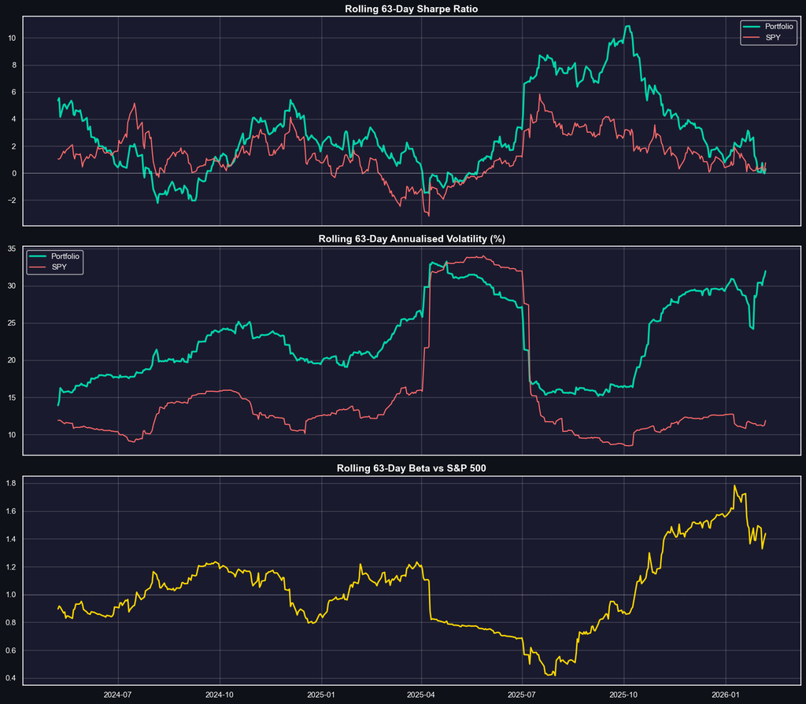

```python
# ============================================================
# 6.2 — Rolling Metrics (Sharpe, Volatility)
# ============================================================

fig, axes = plt.subplots(3, 1, figsize=(16, 14), sharex=True)
fig.patch.set_facecolor('#0e1117')
window = 63  # ~3 months

# Rolling Sharpe
rf_daily = (1 + 0.045) ** (1/252) - 1
for col, color, lw in [('Portfolio', '#00d4aa', 2.5), ('SPY', '#ff6b6b', 1.5)]:
    if col in combined_returns.columns:
        rolling_excess = combined_returns[col] - rf_daily
        rolling_sharpe = rolling_excess.rolling(window).mean() / combined_returns[col].rolling(window).std() * np.sqrt(252)
        axes[0].plot(rolling_sharpe.index, rolling_sharpe, label=col, color=color, linewidth=lw)
axes[0].axhline(y=0, color='white', linewidth=0.5, alpha=0.5)
axes[0].set_title(f'Rolling {window}-Day Sharpe Ratio', fontsize=14, fontweight='bold')
axes[0].legend(facecolor='#1a1a2e', edgecolor='white')
axes[0].grid(alpha=0.2)

# Rolling Volatility
for col, color, lw in [('Portfolio', '#00d4aa', 2.5), ('SPY', '#ff6b6b', 1.5)]:
    if col in combined_returns.columns:
        rolling_vol = combined_returns[col].rolling(window).std() * np.sqrt(252) * 100
        axes[1].plot(rolling_vol.index, rolling_vol, label=col, color=color, linewidth=lw)
axes[1].set_title(f'Rolling {window}-Day Annualised Volatility (%)', fontsize=14, fontweight='bold')
axes[1].legend(facecolor='#1a1a2e', edgecolor='white')
axes[1].grid(alpha=0.2)

# Rolling Beta
if 'SPY' in combined_returns.columns:
    rolling_cov = combined_returns['Portfolio'].rolling(window).cov(combined_returns['SPY'])
    rolling_var = combined_returns['SPY'].rolling(window).var()
    rolling_beta = rolling_cov / rolling_var
    axes[2].plot(rolling_beta.index, rolling_beta, color='#ffd700', linewidth=2)
    axes[2].axhline(y=1, color='white', linewidth=0.5, alpha=0.5, linestyle='--')
    axes[2].set_title(f'Rolling {window}-Day Beta vs S&P 500', fontsize=14, fontweight='bold')
    axes[2].grid(alpha=0.2)

plt.tight_layout()
plt.savefig('rolling_metrics.png', bbox_inches='tight', facecolor='#0e1117')
plt.show()
```

## 7. Drawdown Analysis & Underwater Chart

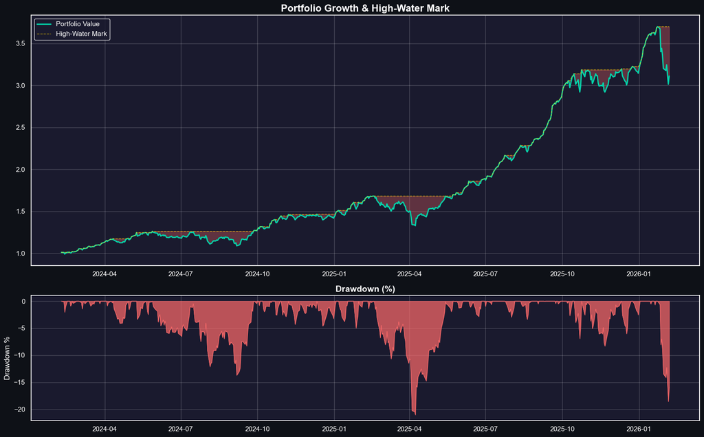

```
Max Drawdown: -21.00%
Current Drawdown: -15.88%
Days in current drawdown: 1
```

```python
# ============================================================
# 7.1 — Underwater Chart
# ============================================================

fig, axes = plt.subplots(2, 1, figsize=(16, 10), gridspec_kw={'height_ratios': [2, 1]})
fig.patch.set_facecolor('#0e1117')

# Cumulative wealth
cum_wealth = (1 + combined_returns['Portfolio']).cumprod()
running_max = cum_wealth.cummax()
drawdown = (cum_wealth - running_max) / running_max * 100

# Top panel: wealth with high-water mark
axes[0].plot(cum_wealth.index, cum_wealth, color='#00d4aa', linewidth=2, label='Portfolio Value')
axes[0].plot(running_max.index, running_max, color='#ffd700', linewidth=1, alpha=0.7,
             linestyle='--', label='High-Water Mark')
axes[0].fill_between(cum_wealth.index, cum_wealth, running_max, alpha=0.3, color='#ff6b6b')
axes[0].set_title('Portfolio Growth & High-Water Mark', fontsize=16, fontweight='bold')
axes[0].legend(facecolor='#1a1a2e', edgecolor='white')
axes[0].grid(alpha=0.2)

# Bottom panel: underwater
axes[1].fill_between(drawdown.index, drawdown, 0, color='#ff6b6b', alpha=0.7)
axes[1].plot(drawdown.index, drawdown, color='#ff6b6b', linewidth=0.5)
axes[1].set_title('Drawdown (%)', fontsize=14, fontweight='bold')
axes[1].set_ylabel('Drawdown %')
axes[1].grid(alpha=0.2)

plt.tight_layout()
plt.savefig('drawdown_analysis.png', bbox_inches='tight', facecolor='#0e1117')
plt.show()

# Top 5 drawdowns
dd_series = drawdown / 100
print(f"\nMax Drawdown: {dd_series.min():.2%}")
print(f"Current Drawdown: {dd_series.iloc[-1]:.2%}")
print(f"Days in current drawdown: {(dd_series.iloc[-1] < 0).sum() if dd_series.iloc[-1] < 0 else 0}")
```

```python
# ============================================================
# 7.2 — Top 5 Drawdown Periods
# ============================================================

def find_drawdown_periods(returns, top_n=5):
    """Find the top N drawdown periods with start, trough, end dates."""
    cum = (1 + returns).cumprod()
    running_max = cum.cummax()
    dd = (cum - running_max) / running_max

    periods = []
    in_dd = False
    start = None

    for i in range(len(dd)):
        if dd.iloc[i] < 0 and not in_dd:
            start = dd.index[i]
            in_dd = True
        elif dd.iloc[i] == 0 and in_dd:
            period_dd = dd[start:dd.index[i]]
            trough_idx = period_dd.idxmin()
            periods.append({
                'Start': start,
                'Trough': trough_idx,
                'End': dd.index[i],
                'Max DD': period_dd.min(),
                'Duration (days)': (dd.index[i] - start).days,
                'Recovery (days)': (dd.index[i] - trough_idx).days
            })
            in_dd = False

    # Handle ongoing drawdown
    if in_dd and start is not None:
        period_dd = dd[start:]
        trough_idx = period_dd.idxmin()
        periods.append({
            'Start': start,
            'Trough': trough_idx,
            'End': 'Ongoing',
            'Max DD': period_dd.min(),
            'Duration (days)': (dd.index[-1] - start).days,
            'Recovery (days)': 'Ongoing'
        })

    periods_df = pd.DataFrame(periods).sort_values('Max DD')
    return periods_df.head(top_n)

dd_periods = find_drawdown_periods(combined_returns['Portfolio'])
print("TOP 5 DRAWDOWN PERIODS")
print("=" * 80)
dd_periods
```

```
TOP 5 DRAWDOWN PERIODS
================================================================================
```

|  | Start | Trough | End | Max DD | Duration (days) | Recovery (days) |
| --- | --- | --- | --- | --- | --- | --- |
| 26 | 2025-02-18 | 2025-04-08 | 2025-05-23 00:00:00 | -0.210024 | 94 | 45 |
| 46 | 2026-01-26 | 2026-02-05 | Ongoing | -0.185289 | 11 | Ongoing |
| 13 | 2024-05-29 | 2024-09-06 | 2024-09-27 00:00:00 | -0.136866 | 121 | 21 |
| 41 | 2025-10-27 | 2025-11-21 | 2025-12-11 00:00:00 | -0.082987 | 45 | 20 |
| 40 | 2025-10-16 | 2025-10-22 | 2025-10-24 00:00:00 | -0.069137 | 8 | 2 |

## 8. Correlation Analysis

### 8.1 Static Correlation Matrix

Full pairwise correlation of all holdings over the 2-year period.

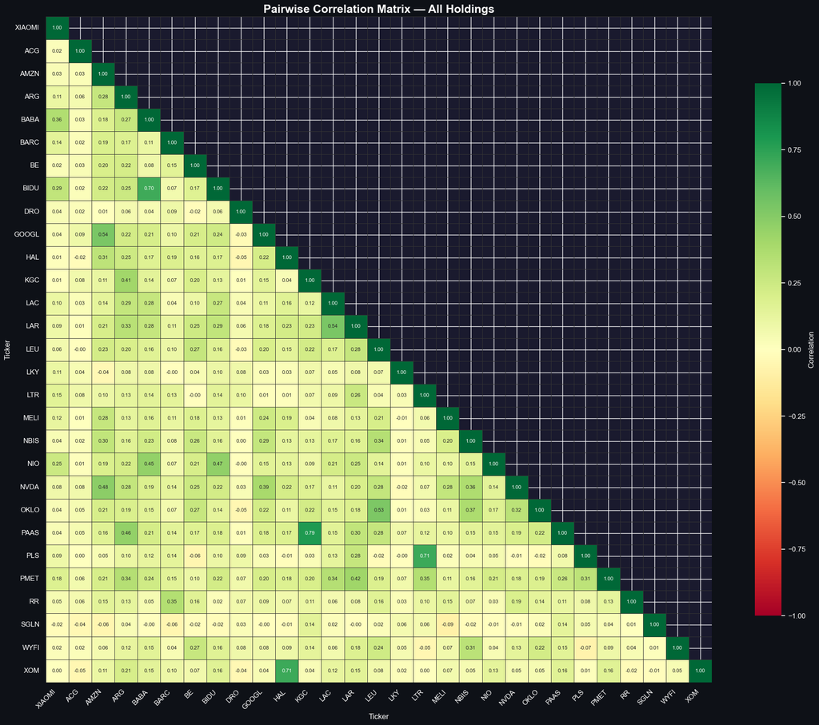

```
Mean pairwise correlation: 0.130
Median pairwise correlation: 0.108
Max correlation: 0.785
Min correlation: -0.086
```

```python
# ============================================================
# 8.1 — Static Correlation Matrix (Seaborn Heatmap)
# ============================================================

# Use only portfolio tickers with sufficient data
port_returns_df = returns[port_tickers].dropna(axis=1, thresh=int(len(returns)*0.5))

corr_matrix = port_returns_df.corr()

# Create readable labels
ticker_to_name = {v['yf_ticker']: k for k, v in holdings.items()}
readable_labels = [ticker_to_name.get(t, t) for t in corr_matrix.columns]

fig, ax = plt.subplots(figsize=(20, 16))
fig.patch.set_facecolor('#0e1117')

mask = np.triu(np.ones_like(corr_matrix, dtype=bool), k=1)
sns.heatmap(
    corr_matrix, mask=mask, annot=True, fmt='.2f', cmap='RdYlGn',
    center=0, vmin=-1, vmax=1, square=True,
    xticklabels=readable_labels, yticklabels=readable_labels,
    linewidths=0.5, linecolor='#333',
    cbar_kws={'shrink': 0.8, 'label': 'Correlation'},
    annot_kws={'size': 8}
)
ax.set_title('Pairwise Correlation Matrix — All Holdings', fontsize=18, fontweight='bold', color='white')
plt.xticks(rotation=45, ha='right')
plt.yticks(rotation=0)
plt.tight_layout()
plt.savefig('correlation_matrix.png', bbox_inches='tight', facecolor='#0e1117')
plt.show()

# Summary stats
upper_corr = corr_matrix.where(~np.triu(np.ones(corr_matrix.shape, dtype=bool), k=0))
print(f"Mean pairwise correlation: {upper_corr.stack().mean():.3f}")
print(f"Median pairwise correlation: {upper_corr.stack().median():.3f}")
print(f"Max correlation: {upper_corr.stack().max():.3f}")
print(f"Min correlation: {upper_corr.stack().min():.3f}")
```

```python
# ============================================================
# 8.2 — Interactive Correlation Heatmap (Plotly)
# ============================================================

fig = px.imshow(
    corr_matrix.values,
    x=readable_labels, y=readable_labels,
    color_continuous_scale='RdYlGn',
    zmin=-1, zmax=1,
    title='Interactive Correlation Matrix',
    aspect='equal'
)
fig.update_layout(height=800, width=900)
fig.show()
```

### 8.3 Rolling Correlation Matrix

Visualising how key correlations evolve over time using a 63-day (3-month) rolling window.

```python
# ============================================================
# 8.3 — Rolling Correlations (Interactive Plotly)
# ============================================================

# Select key pairs to track
key_pairs = []
core_tickers_map = {
    'NVDA': 'NVDA', 'GOOGL': 'GOOGL', 'AMZN': 'AMZN',
}
# Find available core tickers
avail_core = [t for t in ['NVDA', 'GOOGL', 'AMZN', 'BABA', 'XOM', 'KGC'] if t in port_returns_df.columns]

# Also map named tickers
for t in ['SGLN.L', 'BARC.L', 'RR.L']:
    if t in port_returns_df.columns:
        avail_core.append(t)

if 'SPY' in returns.columns:
    avail_core.append('SPY')

window = 63
rolling_corrs = {}

# Portfolio vs SPY
if 'SPY' in returns.columns:
    rolling_corrs['Portfolio vs SPY'] = port_returns.rolling(window).corr(returns['SPY'])

# Key individual correlations
pairs_to_track = [
    ('NVDA', 'GOOGL'), ('NVDA', 'AMZN'), ('KGC', 'NVDA'),
    ('BABA', 'NVDA'), ('XOM', 'KGC')
]

for t1, t2 in pairs_to_track:
    if t1 in port_returns_df.columns and t2 in port_returns_df.columns:
        name1 = ticker_to_name.get(t1, t1)
        name2 = ticker_to_name.get(t2, t2)
        rolling_corrs[f'{name1} vs {name2}'] = port_returns_df[t1].rolling(window).corr(port_returns_df[t2])

# SGLN vs NVDA (gold vs tech hedge)
for gold_t in ['SGLN.L', 'KGC']:
    if gold_t in port_returns_df.columns and 'NVDA' in port_returns_df.columns:
        name_g = ticker_to_name.get(gold_t, gold_t)
        rolling_corrs[f'{name_g} vs NVDA (Hedge?)'] = port_returns_df[gold_t].rolling(window).corr(port_returns_df['NVDA'])

rolling_corr_df = pd.DataFrame(rolling_corrs).dropna()

fig = go.Figure()
for col in rolling_corr_df.columns:
    fig.add_trace(go.Scatter(
        x=rolling_corr_df.index, y=rolling_corr_df[col],
        name=col, mode='lines',
        line=dict(width=2)
    ))

fig.add_hline(y=0, line_dash="dash", line_color="white", opacity=0.5)
fig.update_layout(
    title=f'Rolling {window}-Day Correlations — Key Pairs',
    yaxis_title='Correlation',
    hovermode='x unified',
    height=550,
    legend=dict(x=0.01, y=-0.15, orientation='h')
)
fig.show()
```

## 9. Monte Carlo Simulation — VaR & CVaR

Running 10,000 simulated paths over a 252-day (1-year) horizon using bootstrapped daily returns to estimate the probability distribution of portfolio outcomes.

```python
# ============================================================
# 9.1 — Monte Carlo Simulation (10,000 paths)
# ============================================================

np.random.seed(42)
n_sims = 10_000
n_days = 252
initial_value = 98_303

# Use portfolio daily returns for simulation
port_ret_array = port_returns.values

# Bootstrap simulation
sim_returns = np.random.choice(port_ret_array, size=(n_sims, n_days), replace=True)
sim_paths = initial_value * np.cumprod(1 + sim_returns, axis=1)

# Final values
final_values = sim_paths[:, -1]

# VaR and CVaR
var_95 = np.percentile(final_values, 5)
var_99 = np.percentile(final_values, 1)
cvar_95 = final_values[final_values <= var_95].mean()
cvar_99 = final_values[final_values <= var_99].mean()
median_val = np.median(final_values)
mean_val = np.mean(final_values)

print("=" * 60)
print("MONTE CARLO SIMULATION RESULTS (1-Year, 10,000 paths)")
print("=" * 60)
print(f"Starting Value:    £{initial_value:,.0f}")
print(f"Mean Final Value:  £{mean_val:,.0f}  ({(mean_val/initial_value - 1)*100:+.1f}%)")
print(f"Median Final:      £{median_val:,.0f}  ({(median_val/initial_value - 1)*100:+.1f}%)")
print(f"95th Percentile:   £{np.percentile(final_values, 95):,.0f}")
print(f"5th Percentile:    £{np.percentile(final_values, 5):,.0f}")
print(f"\nValue at Risk (95%):  £{initial_value - var_95:,.0f} (portfolio falls to £{var_95:,.0f})")
print(f"Value at Risk (99%):  £{initial_value - var_99:,.0f} (portfolio falls to £{var_99:,.0f})")
print(f"CVaR (95%):           £{initial_value - cvar_95:,.0f} (avg loss in worst 5%)")
print(f"CVaR (99%):           £{initial_value - cvar_99:,.0f} (avg loss in worst 1%)")
print(f"\nProbability of loss:  {(final_values < initial_value).mean()*100:.1f}%")
print(f"Probability of >50% gain: {(final_values > initial_value * 1.5).mean()*100:.1f}%")
```

```
============================================================
MONTE CARLO SIMULATION RESULTS (1-Year, 10,000 paths)
============================================================
Starting Value:    £98,303
Mean Final Value:  £175,787  (+78.8%)
Median Final:      £170,659  (+73.6%)
95th Percentile:   £253,837
5th Percentile:    £115,102

Value at Risk (95%):  £-16,799 (portfolio falls to £115,102)
Value at Risk (99%):  £975 (portfolio falls to £97,328)
CVaR (95%):           £-5,906 (avg loss in worst 5%)
CVaR (99%):           £8,341 (avg loss in worst 1%)

Probability of loss:  1.1%
Probability of >50% gain: 73.0%
```

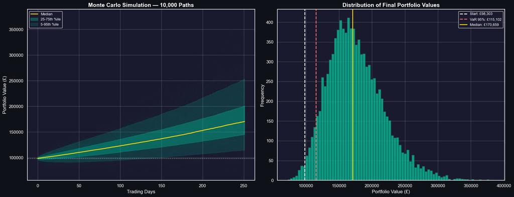

```python
# ============================================================
# 9.2 — Monte Carlo Visualisation
# ============================================================

fig, axes = plt.subplots(1, 2, figsize=(18, 7))
fig.patch.set_facecolor('#0e1117')

# Left: Simulation Paths
for i in range(min(200, n_sims)):
    alpha = 0.03
    color = '#00d4aa' if sim_paths[i, -1] > initial_value else '#ff6b6b'
    axes[0].plot(sim_paths[i], color=color, alpha=alpha, linewidth=0.5)

# Percentile bands
p5 = np.percentile(sim_paths, 5, axis=0)
p25 = np.percentile(sim_paths, 25, axis=0)
p50 = np.percentile(sim_paths, 50, axis=0)
p75 = np.percentile(sim_paths, 75, axis=0)
p95 = np.percentile(sim_paths, 95, axis=0)

axes[0].plot(p50, color='#ffd700', linewidth=2, label='Median')
axes[0].fill_between(range(n_days), p25, p75, alpha=0.3, color='#00d4aa', label='25-75th %ile')
axes[0].fill_between(range(n_days), p5, p95, alpha=0.15, color='#00d4aa', label='5-95th %ile')
axes[0].axhline(y=initial_value, color='white', linewidth=1, linestyle='--', alpha=0.5)
axes[0].set_title('Monte Carlo Simulation — 10,000 Paths', fontsize=14, fontweight='bold')
axes[0].set_xlabel('Trading Days')
axes[0].set_ylabel('Portfolio Value (£)')
axes[0].legend(facecolor='#1a1a2e', edgecolor='white', fontsize=9)
axes[0].grid(alpha=0.2)

# Right: Final Value Distribution
axes[1].hist(final_values, bins=80, color='#00d4aa', alpha=0.7, edgecolor='#333')
axes[1].axvline(x=initial_value, color='white', linewidth=2, linestyle='--', label=f'Start: £{initial_value:,}')
axes[1].axvline(x=var_95, color='#ff6b6b', linewidth=2, linestyle='--', label=f'VaR 95%: £{var_95:,.0f}')
axes[1].axvline(x=median_val, color='#ffd700', linewidth=2, label=f'Median: £{median_val:,.0f}')
axes[1].set_title('Distribution of Final Portfolio Values', fontsize=14, fontweight='bold')
axes[1].set_xlabel('Portfolio Value (£)')
axes[1].set_ylabel('Frequency')
axes[1].legend(facecolor='#1a1a2e', edgecolor='white', fontsize=9)
axes[1].grid(alpha=0.2)

plt.tight_layout()
plt.savefig('monte_carlo.png', bbox_inches='tight', facecolor='#0e1117')
plt.show()
```

## 10. Calendar Heatmap — Daily & Monthly Returns

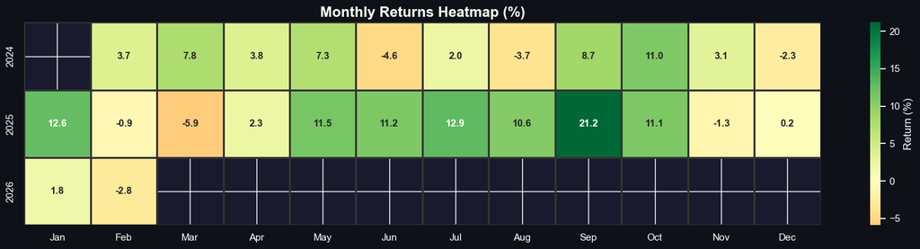

```
Best month:  21.18% (Sep 2025)
Worst month: -5.86% (Mar 2025)
% Positive months: 72%
```

```python
# ============================================================
# 10.1 — Monthly Returns Heatmap
# ============================================================

# Compute monthly returns
monthly_returns = port_returns.resample('ME').apply(lambda x: (1 + x).prod() - 1)
monthly_df = pd.DataFrame({
    'Year': monthly_returns.index.year,
    'Month': monthly_returns.index.month,
    'Return': monthly_returns.values * 100
})

# Pivot for heatmap
monthly_pivot = monthly_df.pivot_table(values='Return', index='Year', columns='Month', aggfunc='first')
monthly_pivot.columns = [calendar.month_abbr[m] for m in monthly_pivot.columns]

fig, ax = plt.subplots(figsize=(16, 4))
fig.patch.set_facecolor('#0e1117')

sns.heatmap(
    monthly_pivot, annot=True, fmt='.1f', cmap='RdYlGn', center=0,
    linewidths=1, linecolor='#333', cbar_kws={'label': 'Return (%)'},
    annot_kws={'size': 11, 'fontweight': 'bold'}
)
ax.set_title('Monthly Returns Heatmap (%)', fontsize=16, fontweight='bold', color='white')
ax.set_ylabel('')
plt.tight_layout()
plt.savefig('monthly_heatmap.png', bbox_inches='tight', facecolor='#0e1117')
plt.show()

# Monthly stats
print(f"Best month:  {monthly_returns.max():.2%} ({monthly_returns.idxmax().strftime('%b %Y')})")
print(f"Worst month: {monthly_returns.min():.2%} ({monthly_returns.idxmin().strftime('%b %Y')})")
print(f"% Positive months: {(monthly_returns > 0).mean():.0%}")
```

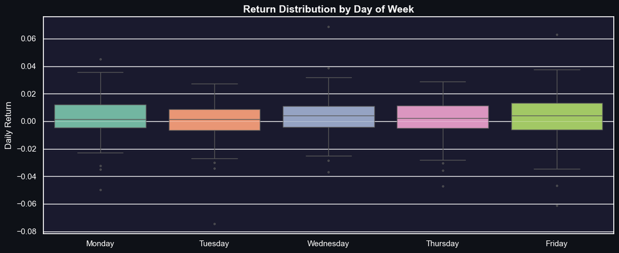

```python
# ============================================================
# 10.2 — Weekly Returns Distribution by Day of Week
# ============================================================

dow_returns = port_returns.copy()
dow_returns = dow_returns.to_frame('ret')
dow_returns['dow'] = dow_returns.index.day_name()
order = ['Monday', 'Tuesday', 'Wednesday', 'Thursday', 'Friday']

fig, ax = plt.subplots(figsize=(12, 5))
fig.patch.set_facecolor('#0e1117')

sns.boxplot(data=dow_returns, x='dow', y='ret', order=order,
            palette='Set2', fliersize=2, ax=ax)
ax.axhline(y=0, color='white', linewidth=0.5, alpha=0.5)
ax.set_title('Return Distribution by Day of Week', fontsize=14, fontweight='bold')
ax.set_xlabel('')
ax.set_ylabel('Daily Return')
plt.tight_layout()
plt.show()
```

## 11. Factor Exposure Analysis (Fama-French)

Regressing portfolio excess returns against Fama-French 3-factor model:

- **MKT-RF**: Market risk premium
- **SMB**: Small minus Big (size factor)
- **HML**: High minus Low (value factor)

We'll use the Kenneth French data library via pandas-datareader or manual download.

```python
# ============================================================
# 11.1 — Fama-French Factor Analysis
# ============================================================

try:
    import pandas_datareader.data as web
    ff_data = web.DataReader('F-F_Research_Data_Factors_daily', 'famafrench',
                             start=start_date, end=end_date)[0]
    ff_data = ff_data / 100  # Convert from percentage
    ff_available = True
    print("✅ Fama-French data loaded from Kenneth French library")
except Exception as e:
    print(f"⚠️ Could not load Fama-French data: {e}")
    print("Falling back to market-only factor model using SPY")
    ff_available = False

if ff_available:
    # Align dates
    ff_aligned = ff_data.reindex(port_returns.index).dropna()
    port_aligned = port_returns.reindex(ff_aligned.index).dropna()

    # Common dates
    common_idx = port_aligned.index.intersection(ff_aligned.index)
    y = port_aligned.loc[common_idx] - ff_aligned.loc[common_idx, 'RF']
    X = ff_aligned.loc[common_idx, ['Mkt-RF', 'SMB', 'HML']]

    # Add constant
    import statsmodels.api as sm
    X_const = sm.add_constant(X)
    model = sm.OLS(y, X_const).fit()

    print("\n" + "=" * 70)
    print("FAMA-FRENCH 3-FACTOR REGRESSION RESULTS")
    print("=" * 70)
    print(model.summary().tables[1])
    print(f"\nR-squared: {model.rsquared:.4f}")
    print(f"Alpha (annualised): {model.params['const'] * 252:.2%}")
    print(f"Alpha t-stat: {model.tvalues['const']:.2f}")
    print(f"Market Beta: {model.params['Mkt-RF']:.3f}")
    print(f"SMB Loading: {model.params['SMB']:.3f} ({'Small cap tilt' if model.params['SMB'] > 0.1 else 'Large cap tilt' if model.params['SMB'] < -0.1 else 'Neutral'})")
    print(f"HML Loading: {model.params['HML']:.3f} ({'Value tilt' if model.params['HML'] > 0.1 else 'Growth tilt' if model.params['HML'] < -0.1 else 'Neutral'})")

else:
    # Simple market model
    if 'SPY' in returns.columns:
        spy_ret = returns['SPY'].reindex(port_returns.index).dropna()
        common = port_returns.index.intersection(spy_ret.index)
        slope, intercept, r, p, se = stats.linregress(spy_ret.loc[common], port_returns.loc[common])
        print(f"\nSimple Market Model:")
        print(f"Beta: {slope:.3f}")
        print(f"Alpha (annual): {intercept * 252:.2%}")
        print(f"R-squared: {r**2:.4f}")
```

```
✅ Fama-French data loaded from Kenneth French library

======================================================================
FAMA-FRENCH 3-FACTOR REGRESSION RESULTS
======================================================================
==============================================================================
                 coef    std err          t      P>|t|      [0.025      0.975]
------------------------------------------------------------------------------
const          0.0019      0.000      4.067      0.000       0.001       0.003
Mkt-RF         0.8054      0.051     15.689      0.000       0.705       0.906
SMB            0.2606      0.072      3.605      0.000       0.119       0.403
HML           -0.3108      0.069     -4.477      0.000      -0.447      -0.174
==============================================================================

R-squared: 0.4949
Alpha (annualised): 48.79%
Alpha t-stat: 4.07
Market Beta: 0.805
SMB Loading: 0.261 (Small cap tilt)
HML Loading: -0.311 (Growth tilt)
```

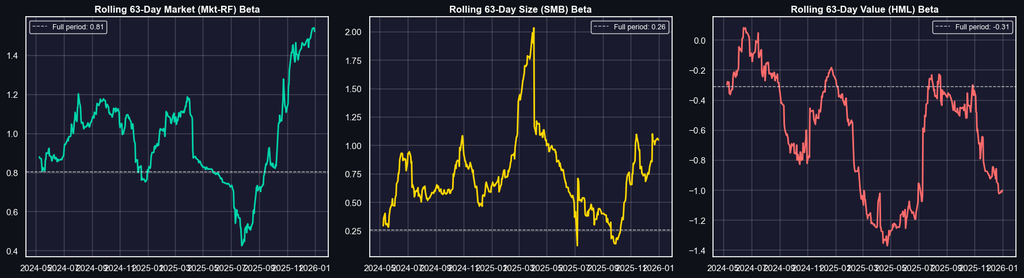

```python
# ============================================================
# 11.2 — Factor Exposure Visualisation
# ============================================================

if ff_available:
    fig, axes = plt.subplots(1, 3, figsize=(18, 5))
    fig.patch.set_facecolor('#0e1117')

    factors = ['Mkt-RF', 'SMB', 'HML']
    colors = ['#00d4aa', '#ffd700', '#ff6b6b']
    titles = ['Market (Mkt-RF)', 'Size (SMB)', 'Value (HML)']

    for i, (factor, color, title) in enumerate(zip(factors, colors, titles)):
        # Rolling beta
        rolling_beta = y.rolling(63).cov(X[factor]) / X[factor].rolling(63).var()
        axes[i].plot(rolling_beta.index, rolling_beta, color=color, linewidth=2)
        axes[i].axhline(y=model.params[factor], color='white', linewidth=1,
                       linestyle='--', alpha=0.7, label=f'Full period: {model.params[factor]:.2f}')
        axes[i].set_title(f'Rolling 63-Day {title} Beta', fontsize=12, fontweight='bold')
        axes[i].legend(facecolor='#1a1a2e', edgecolor='white', fontsize=9)
        axes[i].grid(alpha=0.2)

    plt.tight_layout()
    plt.savefig('factor_exposure.png', bbox_inches='tight', facecolor='#0e1117')
    plt.show()
```

## 12. Riskfolio-Lib Portfolio Optimisation

Using Riskfolio-Lib for:

1. **Mean-Variance Efficient Frontier** — Classic Markowitz optimisation
2. **Risk Parity Portfolio** — Equal risk contribution
3. **Risk Contribution Decomposition** — Understand where risk comes from

```python
# ============================================================
# 12.1 — Prepare Data for Riskfolio
# ============================================================

# Use returns for tickers with sufficient data (at least 252 days)
min_obs = 252
valid_tickers = [t for t in port_tickers if returns[t].dropna().shape[0] >= min_obs]
rf_returns = returns[valid_tickers].dropna()

# Map to readable names
rf_returns.columns = [ticker_to_name.get(t, t) for t in rf_returns.columns]

# Current weights (aligned to valid tickers)
current_w = pd.Series({ticker_to_name.get(t, t): yf_to_weight.get(t, 0) for t in valid_tickers})
current_w = current_w / current_w.sum()  # normalise

print(f"Riskfolio analysis using {len(valid_tickers)} tickers with {len(rf_returns)} observations")
print(f"Tickers: {list(rf_returns.columns)}")
```

```
Riskfolio analysis using 29 tickers with 515 observations
Tickers: ['XIAOMI', 'ACG', 'AMZN', 'ARG', 'BABA', 'BARC', 'BE', 'BIDU', 'DRO', 'GOOGL', 'HAL', 'KGC', 'LAC', 'LAR', 'LEU', 'LKY', 'LTR', 'MELI', 'NBIS', 'NIO', 'NVDA', 'OKLO', 'PAAS', 'PLS', 'PMET', 'RR', 'SGLN', 'WYFI', 'XOM']
```

```python
# ============================================================
# 12.2 — Mean-Variance Efficient Frontier
# ============================================================

# Build portfolio object
port = rp.Portfolio(returns=rf_returns)

# Estimate expected returns and covariance
port.assets_stats(method_mu='hist', method_cov='hist')

# Compute efficient frontier
frontier = port.efficient_frontier(model='Classic', rm='MV', points=50, rf=0.045/252)

print("✅ Efficient frontier computed with 50 points")

# Fix: Compute minimum variance correctly
min_vols = []
for i in range(frontier.shape[1]):
    w = frontier.iloc[:, i].values.flatten()
    vol = np.sqrt(w @ port.cov.values @ w) * np.sqrt(252)
    min_vols.append(vol)

print(f"Minimum variance portfolio volatility: {min(min_vols):.2%}")
```

```
✅ Efficient frontier computed with 50 points
Minimum variance portfolio volatility: 13.52%
```

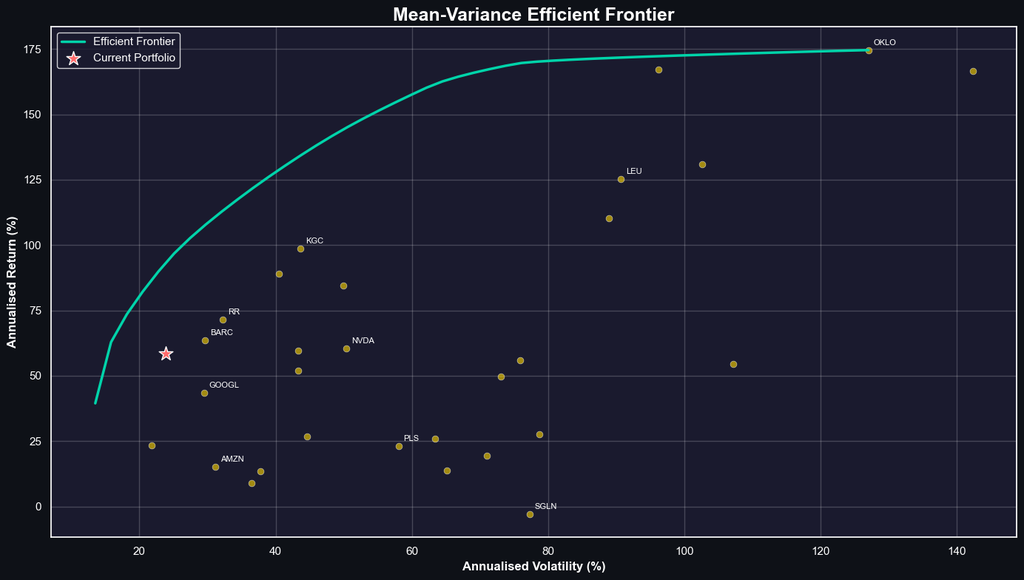

```
Current Portfolio — Return: 58.5%, Vol: 23.9%
```

```python
# ============================================================
# 12.3 — Plot Efficient Frontier
# ============================================================

fig, ax = plt.subplots(figsize=(14, 8))
fig.patch.set_facecolor('#0e1117')

# Plot frontier points
frontier_returns = []
frontier_risks = []

for i in range(frontier.shape[1]):
    w = frontier.iloc[:, i].values.flatten()
    ret = w @ port.mu.values.flatten() * 252
    risk = np.sqrt(w @ port.cov.values @ w) * np.sqrt(252)
    frontier_returns.append(ret)
    frontier_risks.append(risk)

ax.plot(np.array(frontier_risks) * 100, np.array(frontier_returns) * 100,
        color='#00d4aa', linewidth=2.5, label='Efficient Frontier', zorder=5)

# Plot individual assets
asset_rets = port.mu.values.flatten() * 252
asset_vols = np.sqrt(np.diag(port.cov.values)) * np.sqrt(252)

for i, name in enumerate(rf_returns.columns):
    ax.scatter(asset_vols[i] * 100, asset_rets[i] * 100, s=40, zorder=4, alpha=0.6,
               color='#ffd700', edgecolor='white', linewidth=0.5)
    if current_w.get(name, 0) > 0.03:  # Label top holdings
        ax.annotate(name, (asset_vols[i] * 100, asset_rets[i] * 100),
                   fontsize=8, color='white', xytext=(5, 5),
                   textcoords='offset points')

# Plot current portfolio
port_ret_annual = current_w.values @ port.mu.values.flatten() * 252
port_vol_annual = np.sqrt(current_w.values @ port.cov.values @ current_w.values) * np.sqrt(252)
ax.scatter(port_vol_annual * 100, port_ret_annual * 100, s=200, color='#ff6b6b',
           marker='*', zorder=10, label=f'Current Portfolio', edgecolor='white', linewidth=1)

ax.set_xlabel('Annualised Volatility (%)', fontweight='bold', fontsize=12)
ax.set_ylabel('Annualised Return (%)', fontweight='bold', fontsize=12)
ax.set_title('Mean-Variance Efficient Frontier', fontsize=18, fontweight='bold')
ax.legend(facecolor='#1a1a2e', edgecolor='white', fontsize=11)
ax.grid(alpha=0.2)
plt.tight_layout()
plt.savefig('efficient_frontier.png', bbox_inches='tight', facecolor='#0e1117')
plt.show()

print(f"Current Portfolio — Return: {port_ret_annual*100:.1f}%, Vol: {port_vol_annual*100:.1f}%")
```

```python
# ============================================================
# 12.4 — Optimal Portfolios: Max Sharpe & Min Variance
# ============================================================

# Max Sharpe
port_ms = rp.Portfolio(returns=rf_returns)
port_ms.assets_stats(method_mu='hist', method_cov='hist')
w_max_sharpe = port_ms.optimization(model='Classic', rm='MV', obj='Sharpe', rf=0.045/252)

# Min Variance
port_mv = rp.Portfolio(returns=rf_returns)
port_mv.assets_stats(method_mu='hist', method_cov='hist')
w_min_var = port_mv.optimization(model='Classic', rm='MV', obj='MinRisk', rf=0.045/252)

# Display top holdings
print("=" * 60)
print("MAX SHARPE PORTFOLIO — Top 10 Holdings")
print("=" * 60)
# Convert to Series and filter
w_ms_series = w_max_sharpe.iloc[:, 0]
top_ms = w_ms_series[w_ms_series > 0.01].sort_values(ascending=False).head(10)
for name, weight in top_ms.items():
    print(f"  {name:12s}: {weight*100:.1f}%")

print(f"\n{'=' * 60}")
print("MIN VARIANCE PORTFOLIO — Top 10 Holdings")
print("=" * 60)
# Convert to Series and filter
w_mv_series = w_min_var.iloc[:, 0]
top_mv = w_mv_series[w_mv_series > 0.01].sort_values(ascending=False).head(10)
for name, weight in top_mv.items():
    print(f"  {name:12s}: {weight*100:.1f}%")
```

```
============================================================
MAX SHARPE PORTFOLIO — Top 10 Holdings
============================================================
  RR          : 18.5%
  BARC        : 15.7%
  KGC         : 15.4%
  XOM         : 12.9%
  XIAOMI      : 9.5%
  GOOGL       : 8.1%
  ARG         : 6.6%
  DRO         : 4.8%
  BE          : 3.3%
  LKY         : 2.6%

============================================================
MIN VARIANCE PORTFOLIO — Top 10 Holdings
============================================================
  XOM         : 36.0%
  GOOGL       : 11.7%
  RR          : 10.4%
  BARC        : 8.6%
  XIAOMI      : 6.9%
  MELI        : 5.2%
  KGC         : 4.2%
  AMZN        : 4.0%
  SGLN        : 3.3%
  ACG         : 3.2%
```

```python
# ============================================================
# 12.5 — Risk Parity Portfolio
# ============================================================

port_rp = rp.Portfolio(returns=rf_returns)
port_rp.assets_stats(method_mu='hist', method_cov='hist')

# Risk parity optimisation
w_risk_parity = port_rp.rp_optimization(
    model='Classic',
    rm='MV',
    rf=0.045/252,
    b=None  # Equal risk budget
)

print("=" * 60)
print("RISK PARITY PORTFOLIO — Top 15 Holdings")
print("=" * 60)
top_rp = w_risk_parity.sort_values(by=w_risk_parity.columns[0], ascending=False).head(15)
for name in top_rp.index:
    val = top_rp.loc[name].values[0]
    print(f"  {name:12s}: {val*100:.1f}%")
```

```
============================================================
RISK PARITY PORTFOLIO — Top 15 Holdings
============================================================
  XOM         : 9.9%
  BARC        : 6.3%
  RR          : 6.1%
  GOOGL       : 5.2%
  MELI        : 5.0%
  XIAOMI      : 4.8%
  AMZN        : 4.6%
  HAL         : 4.4%
  SGLN        : 4.3%
  ACG         : 4.2%
  PLS         : 3.7%
  KGC         : 3.6%
  WYFI        : 3.2%
  ARG         : 3.0%
  BABA        : 3.0%
```

```python
# ============================================================
# 12.6 — Risk Contribution Decomposition (Current Portfolio)
# ============================================================

# Compute risk contribution of current weights
cov_matrix = port.cov.values
w_current = current_w.values

# Marginal risk contribution
port_vol = np.sqrt(w_current @ cov_matrix @ w_current)
marginal_rc = (cov_matrix @ w_current) / port_vol
component_rc = w_current * marginal_rc
pct_rc = component_rc / component_rc.sum() * 100

# Build DataFrame
rc_df = pd.DataFrame({
    'Weight (%)': current_w.values * 100,
    'Risk Contribution (%)': pct_rc,
    'Weight/Risk Ratio': (current_w.values * 100) / pct_rc
}, index=current_w.index).sort_values('Risk Contribution (%)', ascending=False)

print("=" * 70)
print("RISK CONTRIBUTION DECOMPOSITION — Current Portfolio")
print("=" * 70)
print(f"{'Holding':<12} {'Weight':>8} {'Risk Contr.':>12} {'W/R Ratio':>10}")
print("-" * 45)
for name, row in rc_df.head(15).iterrows():
    print(f"{name:<12} {row['Weight (%)']:>7.1f}%  {row['Risk Contribution (%)']:>10.1f}%  {row['Weight/Risk Ratio']:>9.2f}")
```

```
======================================================================
RISK CONTRIBUTION DECOMPOSITION — Current Portfolio
======================================================================
Holding        Weight  Risk Contr.  W/R Ratio
---------------------------------------------
OKLO             5.3%        18.1%       0.30
SGLN             9.2%         9.8%       0.94
LEU              4.2%         9.5%       0.44
GOOGL            9.7%         5.7%       1.71
KGC              6.5%         5.5%       1.18
AMZN             7.4%         4.6%       1.60
BE               2.5%         4.4%       0.57
PLS              6.4%         4.4%       1.45
NVDA             3.9%         4.3%       0.92
NBIS             2.3%         4.2%       0.54
LAC              1.7%         2.8%       0.59
LAR              1.8%         2.8%       0.65
PMET             1.6%         2.5%       0.64
WYFI             2.8%         2.4%       1.15
BABA             2.9%         2.2%       1.32
```

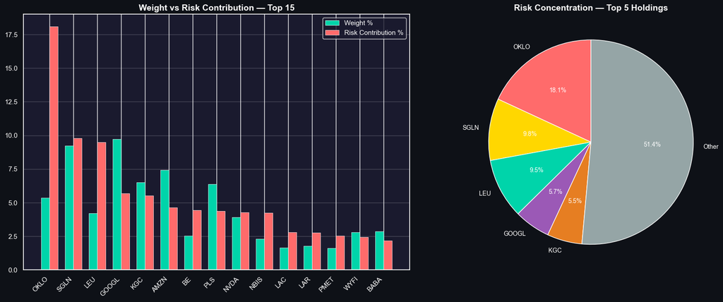

```python
# ============================================================
# 12.7 — Risk Contribution Bar Chart
# ============================================================

fig, axes = plt.subplots(1, 2, figsize=(18, 7))
fig.patch.set_facecolor('#0e1117')

top15 = rc_df.head(15)

# Weight vs Risk Contribution
x = np.arange(len(top15))
width = 0.35

axes[0].bar(x - width/2, top15['Weight (%)'], width, label='Weight %',
           color='#00d4aa', edgecolor='white', linewidth=0.5)
axes[0].bar(x + width/2, top15['Risk Contribution (%)'], width, label='Risk Contribution %',
           color='#ff6b6b', edgecolor='white', linewidth=0.5)
axes[0].set_xticks(x)
axes[0].set_xticklabels(top15.index, rotation=45, ha='right')
axes[0].set_title('Weight vs Risk Contribution — Top 15', fontsize=14, fontweight='bold')
axes[0].legend(facecolor='#1a1a2e', edgecolor='white')
axes[0].grid(alpha=0.2, axis='y')

# Risk concentration pie
top5_rc = rc_df['Risk Contribution (%)'].head(5)
rest_rc = rc_df['Risk Contribution (%)'].iloc[5:].sum()
pie_data = pd.concat([top5_rc, pd.Series({'Other': rest_rc})])
colors_pie = ['#ff6b6b', '#ffd700', '#00d4aa', '#9b59b6', '#e67e22', '#95a5a6']
axes[1].pie(pie_data.values, labels=pie_data.index, autopct='%1.1f%%',
           colors=colors_pie, startangle=90,
           textprops={'color': 'white', 'fontsize': 10})
axes[1].set_title('Risk Concentration — Top 5 Holdings', fontsize=14, fontweight='bold')

plt.tight_layout()
plt.savefig('risk_contribution.png', bbox_inches='tight', facecolor='#0e1117')
plt.show()
```

## 13. Individual Holding Performance

```python
# ============================================================
# 13.1 — Individual Returns Summary
# ============================================================

# Compute total return for each holding
individual_perf = {}
for name, info in holdings.items():
    ticker = info['yf_ticker']
    if ticker in prices.columns:
        p = prices[ticker].dropna()
        if len(p) > 20:
            total_ret = (p.iloc[-1] / p.iloc[0] - 1) * 100
            vol = returns[ticker].dropna().std() * np.sqrt(252) * 100
            sharpe = (returns[ticker].dropna().mean() * 252 - 0.045) / (returns[ticker].dropna().std() * np.sqrt(252)) if returns[ticker].dropna().std() > 0 else 0
            max_dd = ((p / p.cummax()) - 1).min() * 100
            individual_perf[name] = {
                'Total Return (%)': total_ret,
                'Ann. Volatility (%)': vol,
                'Sharpe': sharpe,
                'Max Drawdown (%)': max_dd,
                'Weight (%)': info['weight'],
                'Contribution': total_ret * info['weight'] / 100,
                'Theme': info['theme']
            }

perf_df = pd.DataFrame(individual_perf).T.sort_values('Contribution', ascending=False)
perf_df = perf_df.round(2)

print("INDIVIDUAL HOLDING PERFORMANCE — Sorted by Return Contribution")
print("=" * 90)
perf_df[['Weight (%)', 'Total Return (%)', 'Ann. Volatility (%)', 'Sharpe', 'Max Drawdown (%)', 'Contribution']]
```

```
INDIVIDUAL HOLDING PERFORMANCE — Sorted by Return Contribution
==========================================================================================
```

|  | Weight (%) | Total Return (%) | Ann. Volatility (%) | Sharpe | Max Drawdown (%) | Contribution |
| --- | --- | --- | --- | --- | --- | --- |
| KGC | 5.51 | 516.560205 | 43.636407 | 2.159762 | -18.527921 | 28.462467 |
| OKLO | 4.52 | 570.122533 | 127.02181 | 1.33895 | -69.336257 | 25.769539 |
| BE | 2.15 | 1141.579801 | 96.218568 | 1.69084 | -46.82353 | 24.543966 |
| LEU | 3.56 | 466.115161 | 90.655319 | 1.331656 | -54.148765 | 16.5937 |
| RR | 4.38 | 286.891009 | 32.262612 | 2.074776 | -21.776577 | 12.565826 |
| BARC | 4.87 | 234.896532 | 29.654627 | 1.992974 | -22.37392 | 11.439461 |
| GOOGL | 8.23 | 122.945236 | 29.480829 | 1.32537 | -29.805868 | 10.118393 |
| NBIS | 1.94 | 330.499992 | 88.928635 | 1.188207 | -58.269192 | 6.4117 |
| ARG | 1.52 | 420.871823 | 40.470182 | 2.088038 | -24.135618 | 6.397252 |
| DRO | 1.52 | 391.525462 | 102.663291 | 1.230994 | -77.307692 | 5.951187 |
| NVDA | 3.32 | 166.385221 | 50.35953 | 1.113953 | -36.881027 | 5.523989 |
| PAAS | 1.65 | 334.092514 | 49.921744 | 1.601175 | -23.15963 | 5.512526 |
| BABA | 2.43 | 138.553727 | 43.309313 | 1.093618 | -32.662461 | 3.366856 |
| XIAOMI | 1.34 | 178.763872 | 43.342896 | 1.273306 | -43.54115 | 2.395436 |
| AMZN | 6.28 | 23.834204 | 31.128869 | 0.34667 | -30.876638 | 1.496788 |
| XOM | 2.23 | 53.689764 | 21.769347 | 0.868789 | -18.91814 | 1.197282 |
| LAR | 1.52 | 63.34952 | 73.105231 | 0.619877 | -69.434628 | 0.962913 |
| LTR | 1.23 | 75.789471 | 75.899664 | 0.677613 | -70.90301 | 0.93221 |
| BIDU | 2.18 | 41.446152 | 44.631124 | 0.500136 | -33.240682 | 0.903526 |
| PLS | 5.39 | 13.812155 | 58.028776 | 0.318773 | -74.263038 | 0.744475 |
| LKY | 0.16 | 369.696976 | 142.338041 | 1.138177 | -75.968991 | 0.591515 |
| WYFI | 2.36 | 14.457468 | 63.424145 | 0.337979 | -63.787376 | 0.341196 |
| MELI | 1.47 | 13.69552 | 37.771583 | 0.237676 | -27.313733 | 0.201324 |
| LAC | 1.4 | 13.106796 | 107.151849 | 0.466692 | -70.980925 | 0.183495 |
| HAL | 2.09 | 5.002176 | 36.459712 | 0.123894 | -52.20251 | 0.104545 |
| PMET | 1.38 | -4.984893 | 78.675958 | 0.292662 | -81.041667 | -0.068792 |
| NIO | 1.33 | -13.402065 | 65.144269 | 0.144382 | -56.449375 | -0.178247 |
| ACG | 0.78 | -25.365854 | 70.975801 | 0.209362 | -79.121951 | -0.197854 |
| SGLN | 7.8 | -97.750639 | 77.308136 | -0.095099 | -99.168504 | -7.62455 |

```python
# ============================================================
# 13.2 — Return Contribution Waterfall (Plotly)
# ============================================================

perf_sorted = perf_df.sort_values('Contribution', ascending=False)
colors = ['#00d4aa' if x > 0 else '#ff6b6b' for x in perf_sorted['Contribution']]

fig = go.Figure(go.Bar(
    x=perf_sorted.index,
    y=perf_sorted['Contribution'],
    marker_color=colors,
    text=[f"{v:.1f}" for v in perf_sorted['Contribution']],
    textposition='outside',
    textfont=dict(size=9)
))
fig.update_layout(
    title='Return Contribution by Holding (Return × Weight)',
    yaxis_title='Weighted Return Contribution (%)',
    height=500,
    xaxis_tickangle=45,
    showlegend=False
)
fig.show()
```

```python
# ============================================================
# 13.3 — Risk vs Return Scatter (Interactive)
# ============================================================


# Convert to pandas DataFrame and ensure all columns are native types
perf_plot = perf_df.reset_index()

# Convert each column to native Python types explicitly
converted_data = {}
for col in perf_plot.columns:
    series = perf_plot[col]
    if hasattr(series, '__array__'):
        # Convert to numpy array first, then to list to ensure native types
        converted_data[col] = series.__array__().tolist()
    else:
        # Fallback to to_list()
        converted_data[col] = series.tolist()

# Create a clean pandas DataFrame with native types
perf_plot = pd.DataFrame(converted_data)

fig = px.scatter(
    perf_plot,
    x='Ann. Volatility (%)',
    y='Total Return (%)',
    size='Weight (%)',
    color='Theme',
    text='index',
    title='Risk-Return Scatter — Bubble Size = Portfolio Weight',
    height=600
)
fig.update_traces(textposition='top center', textfont_size=9)
fig.add_hline(y=0, line_dash="dash", line_color="white", opacity=0.3)
fig.update_layout(xaxis_title='Annualised Volatility (%)', yaxis_title='Total Return (%)')
fig.show()
```

## 14. PyFolio-Style Analysis

Replicating key components of pyfolio tear sheets for the portfolio.

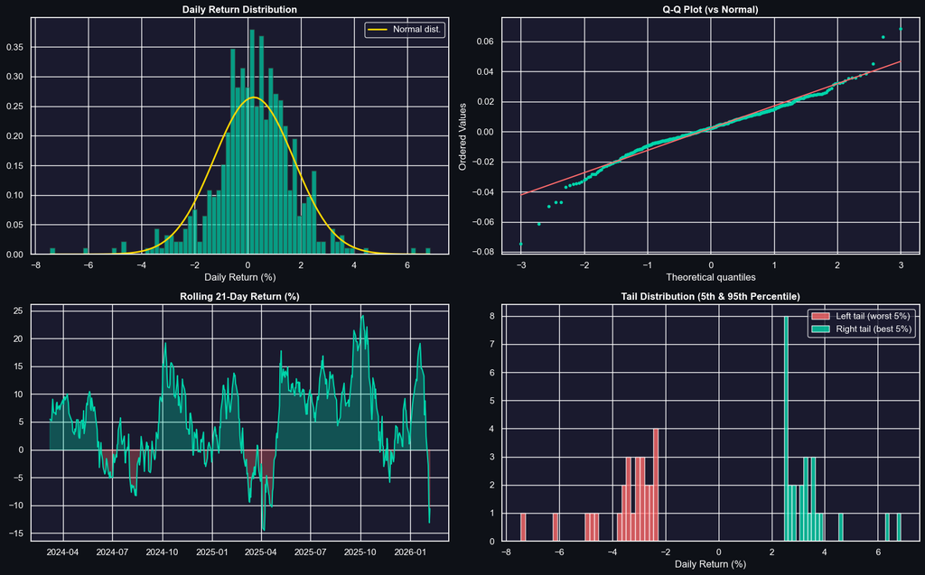

```python
# ============================================================
# 14.1 — Return Distribution Analysis
# ============================================================

fig, axes = plt.subplots(2, 2, figsize=(16, 10))
fig.patch.set_facecolor('#0e1117')

# Return distribution
axes[0,0].hist(port_returns * 100, bins=80, color='#00d4aa', alpha=0.7, edgecolor='#333', density=True)
# Overlay normal distribution
x_range = np.linspace(port_returns.min() * 100, port_returns.max() * 100, 100)
normal_pdf = stats.norm.pdf(x_range, port_returns.mean() * 100, port_returns.std() * 100)
axes[0,0].plot(x_range, normal_pdf, color='#ffd700', linewidth=2, label='Normal dist.')
axes[0,0].axvline(x=0, color='white', linewidth=0.5, alpha=0.5)
axes[0,0].set_title('Daily Return Distribution', fontsize=12, fontweight='bold')
axes[0,0].set_xlabel('Daily Return (%)')
axes[0,0].legend(facecolor='#1a1a2e', edgecolor='white')

# QQ Plot
stats.probplot(port_returns.values, dist="norm", plot=axes[0,1])
axes[0,1].set_title('Q-Q Plot (vs Normal)', fontsize=12, fontweight='bold')
axes[0,1].get_lines()[0].set_color('#00d4aa')
axes[0,1].get_lines()[0].set_markersize(3)
axes[0,1].get_lines()[1].set_color('#ff6b6b')

# Rolling 30-day return
rolling_30d = port_returns.rolling(21).sum() * 100
axes[1,0].plot(rolling_30d.index, rolling_30d, color='#00d4aa', linewidth=1.5)
axes[1,0].axhline(y=0, color='white', linewidth=0.5, alpha=0.5)
axes[1,0].fill_between(rolling_30d.index, rolling_30d, 0,
                        where=rolling_30d > 0, alpha=0.3, color='#00d4aa')
axes[1,0].fill_between(rolling_30d.index, rolling_30d, 0,
                        where=rolling_30d < 0, alpha=0.3, color='#ff6b6b')
axes[1,0].set_title('Rolling 21-Day Return (%)', fontsize=12, fontweight='bold')

# Tail analysis
axes[1,1].hist(port_returns[port_returns < port_returns.quantile(0.05)] * 100,
               bins=30, color='#ff6b6b', alpha=0.8, label='Left tail (worst 5%)')
axes[1,1].hist(port_returns[port_returns > port_returns.quantile(0.95)] * 100,
               bins=30, color='#00d4aa', alpha=0.8, label='Right tail (best 5%)')
axes[1,1].set_title('Tail Distribution (5th & 95th Percentile)', fontsize=12, fontweight='bold')
axes[1,1].set_xlabel('Daily Return (%)')
axes[1,1].legend(facecolor='#1a1a2e', edgecolor='white')

plt.tight_layout()
plt.savefig('return_distribution.png', bbox_inches='tight', facecolor='#0e1117')
plt.show()
```

```python
# ============================================================
# 14.2 — PyFolio Tear Sheet (if available)
# ============================================================

try:
    import pyfolio as pf

    # Create tear sheet
    print("Generating PyFolio performance summary...")
    print("=" * 60)

    # Performance stats
    perf_stats = pf.timeseries.perf_stats(port_returns)
    print(perf_stats)

except Exception as e:
    print(f"PyFolio tear sheet not fully available: {e}")
    print("Key metrics already computed above.")
```

```
Generating PyFolio performance summary...
============================================================
Annual return          0.742489
Cumulative returns     2.110766
Annual volatility      0.239075
Sharpe ratio           2.444883
Calmar ratio           3.535260
Stability              0.899870
Max drawdown          -0.210024
Omega ratio            1.519871
Sortino ratio          3.698811
Skew                  -0.378828
Kurtosis               3.035572
Tail ratio             1.095680
Daily value at risk   -0.027801
dtype: float64
```

## 15. Portfolio Health Check & Risk Alerts

Automated checks for concentration risk, correlation clustering, and position sizing.

```python
# ============================================================
# 15.1 — Portfolio Health Dashboard
# ============================================================

print("=" * 70)
print("🏥 PORTFOLIO HEALTH CHECK")
print("=" * 70)

# 1. Concentration
top5_weight = portfolio_df.nlargest(5, 'weight_norm')['weight_norm'].sum()
hhi = (portfolio_df['weight_norm'] / 100).pow(2).sum()
effective_n = 1 / hhi

print(f"\n📊 CONCENTRATION:")
print(f"  Top 5 holdings weight: {top5_weight:.1f}%  {'⚠️ HIGH' if top5_weight > 40 else '✅ OK'}")
print(f"  HHI (Herfindahl): {hhi:.4f}  {'⚠️ Concentrated' if hhi > 0.10 else '✅ Diversified'}")
print(f"  Effective # of holdings: {effective_n:.1f}  (out of {len(holdings)})")

# 2. Sector concentration
max_sector = sector_weights.max()
print(f"\n🏭 SECTOR:")
print(f"  Largest sector: {sector_weights.idxmax()} ({max_sector:.1f}%)  {'⚠️ HIGH' if max_sector > 35 else '✅ OK'}")

# 3. Geographic concentration
max_geo = max(geo_weights.values())
max_geo_name = max(geo_weights, key=geo_weights.get)
print(f"\n🌍 GEOGRAPHIC:")
print(f"  Largest country: {max_geo_name} ({max_geo:.1f}%)  {'⚠️ HIGH' if max_geo > 50 else '✅ OK'}")

# 4. Correlation risk
if len(corr_matrix) > 1:
    high_corr_pairs = []
    for i in range(len(corr_matrix)):
        for j in range(i+1, len(corr_matrix)):
            if abs(corr_matrix.iloc[i, j]) > 0.7:
                high_corr_pairs.append(
                    (corr_matrix.index[i], corr_matrix.columns[j], corr_matrix.iloc[i, j])
                )

    print(f"\n🔗 CORRELATION RISK:")
    print(f"  Highly correlated pairs (|ρ| > 0.7): {len(high_corr_pairs)}")
    for t1, t2, rho in sorted(high_corr_pairs, key=lambda x: -abs(x[2]))[:5]:
        n1 = ticker_to_name.get(t1, t1)
        n2 = ticker_to_name.get(t2, t2)
        print(f"    {n1} ↔ {n2}: ρ = {rho:.2f}")

# 5. Overall risk
print(f"\n⚡ RISK SUMMARY:")
print(f"  Portfolio VaR (95%, daily): {np.percentile(port_returns, 5)*100:.2f}%  (£{abs(np.percentile(port_returns, 5)) * 98303:.0f})")
print(f"  Max Drawdown: {((1 + port_returns).cumprod() / (1 + port_returns).cumprod().cummax() - 1).min():.2%}")
print(f"  Annualised Vol: {port_returns.std() * np.sqrt(252) * 100:.1f}%")

# 6. Recommendations
print(f"\n💡 OBSERVATIONS:")
if top5_weight > 40:
    print("  → Top 5 concentration above 40% — consider trimming largest positions")
if max_sector > 35:
    print(f"  → {sector_weights.idxmax()} sector weight elevated — monitor sector risk")
if max_geo > 50:
    print(f"  → Geographic concentration in {max_geo_name} — consider international diversification")
if len(high_corr_pairs) > 5:
    print("  → Multiple highly correlated pairs reduce effective diversification")
```

```
======================================================================
🏥 PORTFOLIO HEALTH CHECK
======================================================================

📊 CONCENTRATION:
  Top 5 holdings weight: 39.3%  ✅ OK
  HHI (Herfindahl): 0.0517  ✅ Diversified
  Effective # of holdings: 19.3  (out of 29)

🏭 SECTOR:
  Largest sector: Technology (35.0%)  ✅ OK

🌍 GEOGRAPHIC:
  Largest country: US (39.7%)  ✅ OK

🔗 CORRELATION RISK:
  Highly correlated pairs (|ρ| > 0.7): 3
    KGC ↔ PAAS: ρ = 0.79
    HAL ↔ XOM: ρ = 0.71
    LTR ↔ PLS: ρ = 0.71

⚡ RISK SUMMARY:
  Portfolio VaR (95%, daily): -2.24%  (£2197)
  Max Drawdown: -21.00%
  Annualised Vol: 23.9%

💡 OBSERVATIONS:
```

## 16. Executive Summary

### Key Findings

This analysis provides a comprehensive view of the IBKR ISA portfolio across multiple dimensions:

**Performance:** Cumulative return vs benchmarks, monthly patterns, and factor attribution.

**Risk:** VaR/CVaR, Monte Carlo projections, drawdown analysis, and correlation structure.

**Optimisation:** Efficient frontier positioning, risk parity allocation, and risk contribution decomposition highlight where the portfolio sits relative to optimal allocations.

*Analysis generated using: yfinance, Riskfolio-Lib, PyFolio, QuantStats, Seaborn, Matplotlib, Plotly*